# RPESE: Risk and Performance Estimators Standard Errors with Serially Dependent Data

The R package [*RPESE*](https://CRAN.R-project.org/package=RPESE) (Risk and Performance Estimators Standard Errors) implements a new method for computing accurate standard errors of risk and performance estimators when returns are serially dependent. The new method makes use of the representation of a risk or performance estimator as a summation of a time series of influence-function (IF) transformed returns, and computes estimator standard errors using a sophisticated method of estimating the spectral density at frequency zero of the time series of IF-transformed returns. Two additional packages used by [*RPESE*](https://CRAN.R-project.org/package=RPESE) are introduced, namely [*RPEIF*](https://CRAN.R-project.org/package=RPEIF) which computes and provides graphical displays of the IF of risk and performance estimators, and [*RPEGLMEN*](https://CRAN.R-project.org/package=RPEGLMEN) which implements a regularized Gamma generalized linear model polynomial fit to the periodogram of the time series of the IF-transformed returns. A Monte Carlo study shows that the new method provides more accurate estimates of standard errors for risk and performance estimators compared to well-known alternative methods in the presence of serial correlation.

Anthony-Alexander Christidis (University of British Columbia) , R. Doug Martin (University of Washington)  
2022-01-04

## 1 Introduction

In the risk and portfolio management industry, risk and performance estimators are standard tools used in data-driven decision-making processes. The current industry practice in reporting risk and performance estimates for individual assets and portfolios typically do not include their standard error (SE) estimates. For this reason, consumers of such reports have no way of knowing the statistical accuracy of the estimates. As a leading example, one seldom sees SEs reported for Sharpe ratios, and consequently cannot tell whether or not two Sharpe ratios for two different portfolios or assets are significantly different. This motivated the development of the Risk and Performance Estimator Standard Errors package, [*RPESE*](https://CRAN.R-project.org/package=RPESE), for computing risk and performance estimator standard errors that are accurate when returns that are serially correlated and can have fat-tailed and skewed non-normality of returns distributions. [*RPESE*](https://CRAN.R-project.org/package=RPESE) uses a new method for computing risk and performance estimators standard errors developed by Chen and Martin (2021).

In the quantitative finance literature, numerous statistical methods have been proposed to evaluate the variability of risk and performance estimators under the assumption of independent and identically distributed (i.i.d.) returns. These methods are however inadequate when returns are serially correlated. An example of this was provided by Lo (2002), who showed that the Sharpe ratio estimator standard error based on the assumption of i.i.d. returns is overly optimistic when returns are actually serially correlated. In terms of statistical methods to compute standard errors of estimators when working with time series data exhibiting serial correlation, there are two well-known methods in the literature: the nonparametric heteroskedasticity and autocorrelation consistent (HAC) covariance method (Newey and West 1987; Andrews 1991; Zeileis 2004) and the nonparametric block bootstrap method (Kunsch 1989; Politis and Romano 1994). HAC covariance estimators, which rely on a kernel-based approach on the lag-$k$ covariance estimates of the time series, possess desirable statistical properties such as consistency under heteroscedasticity and autocorrelation. Block bootstrap methods have been shown to provide accurate standard errors if they are well calibrated (Ledoit and Wolf 2008). However, they rely on randomness which is an unappealing feature for industry practitioners as different results can be reported on the same data set, albeit small if a large enough number of replicates are used.

Unlike the nonparametric HAC and block bootstrap methods, the method implemented in the [*RPESE*](https://CRAN.R-project.org/package=RPESE) package is a fully parametric and deterministic method for computing risk and performance estimators standard errors for time series with serial correlation, which is an appealing feature for the purpose of constructing confidence intervals and tests. While IFs are commonly used tools in robust statistics, they are seldomly used in quantitative finance research and applications. The new method involves the representation of the risk and performance estimators using influence functions (IFs) and fitting a penalized Gamma generalized linear model (GLM) to the periodogram of the IF-transformed returns time series. The estimate of the variance of the estimator can be obtained from the spectral density estimate of the IF-transformed returns time series at zero frequency, a technique introduced by Heidelberger and Welch (1981).

## 2 New Methodology: Standard Errors via Influence Functions

IFs were first introduced by Hampel (1974), and were developed further by Hampel et al. (1986). In this section, we provide the definition and basic properties of influence functions, with a view toward their use for understanding the influence of outliers on risk and performance estimators, and for computing standard errors of such estimators for both uncorrelated and serially correlated returns.

### 2.1 Risk and Performance Estimator Functional Representations

The large-sample value (as sample size $n$ tends to infinity) of a risk or performance estimator may be represented as a functional $T=T(F)$ of the marginal distribution function $F$ of a time series $r_{1},r_{2},\dots,r_{n}$ of returns.[^1] For example the functional for the mean (expected value) is

$$\label{eq: meanFunctional}
\mu(F)=\int rdF(r) \tag{1}$$
and the functional for the standard deviation (returns volatility) is
$$\label{eq: stdDevFunctional}
\sigma(F)=\bigg[\int(r-\mu(F))^{2}dF(r)\bigg]^{\frac{1}{2}}. \tag{2}$$

Given a functional representation $T(F)$ of an estimator, a finite-sample *non-parametric* estimator $T_{n}$ is easily obtained by replacing the unknown distribution $F$ by the empirical distribution $F_{n}$ that has a jump of height $1/n$ at each of the observed returns values $r_{1},r_{2},\dots,r_{n}$:
$$T_{n}=T(F_{n})=T(r_{1},r_{2},\dots,r_{n}).$$
For example, the finite-sample non-parametric estimators of the mean and standard deviation are the sample mean and sample standard deviation, respectively:
$$\label{eq: sampleMeanAndStdDev}
\hat{\mu}_{n}=\frac{1}{n}\sum_{t=1}^{n}r_{t}\qquad\hat{\sigma}_{n}=\bigg[\frac{1}{n}\sum_{t=1}^{n}(r_{t}-\hat{\mu}_{n})\bigg]^{\frac{1}{2}}. \tag{3}$$

We note that one can also derive parametric estimators from parametric functional representation obtained by replacing $F$ by $F_{\theta}$, where $\theta$ is the parameter vector for a parametric distribution function. In this case one obtains the finite-sample estimator by replacing the unknown parameter by its estimator, typically the maximum-likelihood estimator (MLE). See for example, Martin and Zhang (2019) for a treatment of parametric and non-parametric expected shortfall (ES) estimators for normal and $t$-distributions. However, the current version of the [*RPEIF*](https://CRAN.R-project.org/package=RPEIF) package only deals with non-parametric risk and performance estimators.

### 2.2 Estimator Influence Function Definition

IFs are based on the use of the following mixture distribution perturbation of a fixed target distribution $F(x)$ :
$$F_{\gamma}(x)=(1-\gamma)F(x)+\gamma\delta_{r}(x),\,0\le\gamma<1/2$$
where $\delta_{r}(x)$ is a point mass discrete distribution function with a jump of height one located at value $r$ . The IF of an estimator with functional form $T(F)$ is defined as:
$$IF(r;T,F)=\lim\limits _{\gamma\to0}\frac{T(F_{\gamma})-T(F)}{\gamma}=\frac{d}{d\gamma}T(F_{\gamma})|_{\gamma=0}$$

The IF is a special directional derivative (i.e., a Gateaux derivative) of the functional $T(F)$ in the direction of a point mass distributions $\delta_{r}$, evaluated at $F$. It is straightforward, and more or less tedious, to derive formulas for the IFs of risk and performance estimators. For example, the IF of the sample mean is:
$$\label{eq: IFmuAndStdDev}
IF(r;\mu;F)=r-\mu \tag{4}$$
where $\mu=\mu(F)$ depends on the underlying returns marginal distribution $F$. The above influence function has the property that its expected value is zero, which is a reflection of the general property than an influence function has zero expected value (Hampel 1974):
$$\label{eq: zeroMeanOfIF}
E\left[IF(r;T,F)\right]=0. \tag{5}$$

### 2.3 A Key Influence Function Property

A key IF property is that for well behaved estimator functionals, the finite-sample estimator $T_{n}=T(F_{n})=T(r_{1},r_{2},\dots,r_{n})$ can be expressed in terms of the sample mean of IF transformed returns as
$$T_{n}-T(F)=\frac{1}{n}\sum_{t=1}^{n}IF(r_{t};T,F)+remainder$$
where the remainder goes to zero in a probabilistic sense as $n\to\infty$. Thus the finite sample variance of $T_{n}$ is approximately given by
$$\label{eq: EstVar}
Var\left(T_{n}\right)=Var\left[\frac{1}{n}\sum_{t=1}^{n}IF(r_{t};T,F)\right] \tag{6}$$
and in the special case where the returns $r_{t}$ are i.i.d., the IF-transformed returns are i.i.d., and the variance of $T_{n}$ reduces to
$$\label{eq: iidEstVar}
Var\left(T_{n}\right)=\frac{1}{n}E[IF^{2}(r_{1};T,F)]. \tag{7}$$
and the expectation on the right-hand side can be evaluated empirically as the sample mean of the squared influence functions.

However, when the $r_{t},t=1,2,\dots,n$ are serially dependent, such as in the case of serially correlated AR(1) returns or serially uncorrelated but dependent GARCH(1,1) returns, the IF-transformed returns time series $IF(r_{t};T,F)$ will generally have serial correlation that needs to be accounted for in calculating the variance on the the right-hand-side of ((6)). In particular,
$$\label{eq:corr_eq}
\frac{1}{n} Var\left[\sum_{i=1}^{n} IF(r_t; T, F) \right] = C_{IF}(0) + 2 \sum_{k=1}^{n-1}\left(1 - \frac{k}{n}\right)C_{IF}(k), \tag{8}$$
where $C_{IF}(k)$ is the symmetric lag-$k$ covariance between $IF(r_t)$ and $IF(r_{t+k})$. Spectral analysis theory, extensively used in science and engineering, shows that the variance of the sum of the values of a serially correlated stationary time series is given by the spectral density of the time series at zero frequency. Thus the problem of estimating the variance ((6)), with possibly serially correlated returns, reduces to the problem of estimating the spectral density at zero frequency of the the time series $IF(r_{t};T,F)/n$. Chen and Martin (2021) show how to do this by a polynomial Gamma GLM fitting method, with elastic net (EN) regularization, that works well when the returns are serially correlated, as well as when they are uncorrelated. Their methodology is implemented in the [*RPESE*](https://CRAN.R-project.org/package=RPESE) package, which in turn makes fundamental use of the [*RPEIF*](https://CRAN.R-project.org/package=RPEIF) package to compute and provide graphical displays for the influence functions of popular risk and performance estimators, and the [*RPEGLMEN*](https://CRAN.R-project.org/package=RPEGLMEN) to fit a polynomial Gamma GLM with EN penalty to the IF-transformed returns time series periodogram.

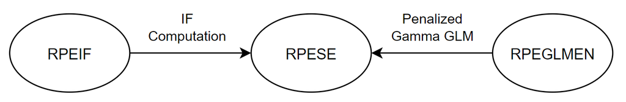

Figure 1: Package relations between [*RPEIF*](https://CRAN.R-project.org/package=RPEIF), [*RPESE*](https://CRAN.R-project.org/package=RPESE) and [*RPEGLMEN*](https://CRAN.R-project.org/package=RPEGLMEN).

## 3 Influence Functions for Risk and Performance Estimators

The current version (1.2.2) of the [*RPESE*](https://CRAN.R-project.org/package=RPESE) package supports six risk and nine performance estimators. The risk estimators are the sample standard deviation (SD), the semi-standard deviation (SemiSD), the lower partial moment of order one and two (LPM1 and LPM2), the expected shortfall (ES) and the value-at-risk (VaR), the latter two risk estimators with tail probability $\alpha$. The performance estimators are the mean (Mean), a robust M-estimator of the mean (robMean) of $\psi$-type[^2], the Sharpe ratio (SR), the downside Sharpe ratio (DSR), the Sortino ratio (SoR) with constant threshold $c$, the expected shortfall ratio (ESratio) and the value-at-risk ratio (VaRratio) with tail probability $\alpha$, the Rachev ratio (RachevRatio) with lower and upper tail probability $\alpha$ and $\beta$, and the Omega ratio (OmegaRatio) with constant threshold $c$.

The formulas for these risk and performance estimators and their functional representations, and the derivations of their influence function formulas, are given in (Zhang et al. 2021). In Table 1, the names of the functions in the [*RPEIF*](https://CRAN.R-project.org/package=RPEIF) and [*RPESE*](https://CRAN.R-project.org/package=RPESE) packages for the risk and performance estimators are provided.

Table 1: Functions in [*RPEIF*](https://CRAN.R-project.org/package=RPEIF) and [*RPESE*](https://CRAN.R-project.org/package=RPESE) for the risk and performance estimators.

| **Risk** | [*RPEIF*](https://CRAN.R-project.org/package=RPEIF) | [*RPESE*](https://CRAN.R-project.org/package=RPESE) |
| --- | --- | --- |
| SD | `IF.SD` | `SD.SE` |
| SemiSD | `IF.SemiSD` | `SemiSD.SE` |
| LPM1 or LPM2 | `IF.LPM` | `LPM.SE` |
| ES | `IF.ES` | `ES.SE` |
| VaR | `IF.VaR` | `VaR.SE` |
| **Performance** | [*RPEIF*](https://CRAN.R-project.org/package=RPEIF) | [*RPESE*](https://CRAN.R-project.org/package=RPESE) |
| Mean | `IF.Mean` | `Mean.SE` |
| robMean | `IF.robMean` | `robMean.SE` |
| SR | `IF.SR` | `SR.SE` |
| DSR | `IF.DSR` | `DSR.SE` |
| SoR | `IF.SoR` | `SoR.SE` |
| ESratio | `IF.ESratio` | `Esratio.SE` |
| VaRratio | `IF.VaRratio` | `VaRratio.SE` |
| RachevRatio | `IF.RachevRatio` | `RachevRatio.SE` |
| OmegaRatio | `IF.OmegaRatio` | `OmegaRatio.SE` |

### 3.1 The [*RPEIF*](https://CRAN.R-project.org/package=RPEIF) Package

The functions in the [*RPEIF*](https://CRAN.R-project.org/package=RPEIF) package listed in Table 1 are used for two distinct purposes. The first is to evaluate an estimator IF at a set of data values, and plot them to display a graph of the influence function. This allows the user to explore the different shapes of the IFs of different estimators. The second and primary purpose of these IF functions is to compute IF-transformed time series of returns, as a first step in the overall method of computing standard errors for risk and performance estimators.

To briefly demonstrate the usage of the [*RPEIF*](https://CRAN.R-project.org/package=RPEIF) package, the `edhec` data set available in the [*PerformanceAnalytics*](https://CRAN.R-project.org/package=PerformanceAnalytics) package will be used. This data set contains hedge fund returns from January, 1997 to November, 2019. The data can be loaded as an `xts` time series object with the following R code.

```r
install.packages("PerformanceAnalystics")
data(edhec, package = "PerformanceAnalytics")
class(edhec)

## [1] "xts" "zoo"
```

The hedge fund names in `edhec` are too long to display well in plots. The following code replaces those long names with shorter names.

```r
colnames(edhec) <- c("CA", "CTAG", "DIS", "EM", "EMN", "ED", "FIA", "GM", "LS", "MA",
                     "RV", "SS", "FoF")
```

The following functions are available in [*RPEIF*](https://CRAN.R-project.org/package=RPEIF):

```r
library(RPEIF)
ls("package:RPEIF")

 [1] "IF"             "IF.DSR"         "IF.ES"          "IF.ESratio"
 [5] "IF.LPM"         "IF.Mean"        "IF.OmegaRatio"  "IF.RachevRatio"
 [9] "IF.robMean"     "IF.SD"          "IF.SemiSD"      "IF.SoR"
[13] "IF.SR"          "IF.VaR"         "IF.VaRratio"    "nuisParsFn"
```

In order to compute the values and plot the shapes of influence functions using the IF functions in Table 1, nuisance parameters need to be specified, and there are two basic methods of doing so. Using the `nuisParsFn` function, nuisance parameters can be generated by specifying "typical" values based on some assumed returns distribution. For the risk measure estimators and performance measure estimators, the `nuisParsFn` function assumes by default that the returns follow the normal distribution, with monthly mean return of $\mu = 1\%$, risk-free rate $rf = 0\%$, monthly volatility of $\sigma=5\%$ (the corresponding annual mean and volatility are 12% and 17.3%, respectively), and in addition assumes by default that $c=0$ for LPM and SoR, $\alpha = 0.10$ for VaR and ES, and in addition $\beta = 0.10$ for the Rachev ratio. Thus:

```r
args(nuisParsFn)

## function (mu = 0.01, sd = 0.05, c = 0, alpha = 0.1, beta = 0.1)
```

To generate nuisance parameters by using a mean return of $2\%$ instead of $1\%$ and a volatility of $15\%$ instead of $5\%$ (the defaults) for the purpose of displaying the IF plots for the SD and the SR, the `nuisPars` argument can be used as in the following code, with the plots shown in Figure 2.

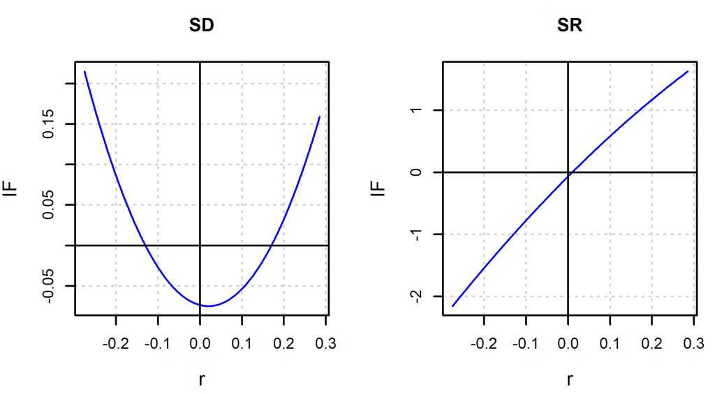

Figure 2: IF shapes of SD and SR with user-specified nuisance parameters.

```r
par(mfrow = c(2, 1))
outSD <- IF.SD(evalShape = T, IFplot = T, nuisPars = nuisParsFn(mu = 0.02, sd = 0.15))
outSR <- IF.SR(evalShape = T, IFplot = T, nuisPars = nuisParsFn(mu = 0.02, sd = 0.15))
```

The second way to specify nuisance parameter values is to estimate them from a returns time series of interest, the latter of which is specified by using the argument `returns` of the IF functions. For example, the Convertible Arbitrage (CA) hedge fund time series can be used for this purpose by using the following code, the results of which are shown in Figure 3.

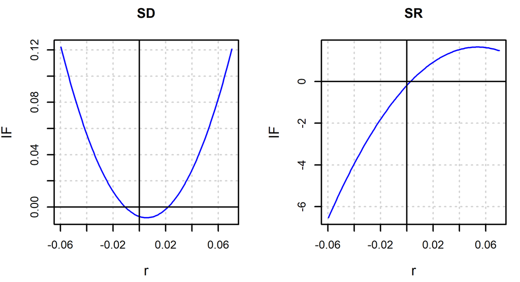

Figure 3: IF shapes of SD and SR with estimated nuisance parameters.

```r
par(mfrow = c(2, 1))
outSD <- IF.SD(returns = edhec$CA, evalShape = T, IFplot = T)
outSR <- IF.SR(returns = edhec$CA, evalShape = T, IFplot = T)
```

To plot the IF-transformed returns of the SD and SR estimators, use the following code to generate the output shown in Figure 4:

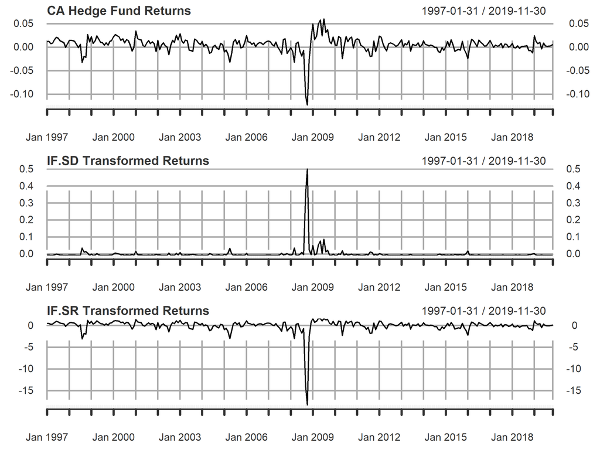

Figure 4: SD and SR IF-transformed returns for CA hedge fund.

```r
SDiftr <- IF.SD(returns = edhec$CA)
SRiftr <- IF.SR(returns = edhec$CA)
par(mfrow = c(3, 1))
plot(edhec$CA, lwd = 0.8, ylab = "Returns", main = "CA Hedge Fund Returns")
plot(SDiftr, lwd = 0.8, main = "IF.SD Transformed Returns")
plot(SRiftr, lwd = 0.8, main = "IF.SR Transformed Returns")
```

Returns data are prone to outliers which adversely influence parameter estimates and inflate the standard errors of risk and performance estimators. A very reliable outlier cleaning method that shrinks outliers can be obtained based on a robust location M-estimator and an associated robust scale estimator $\hat{s}$. A location M-estimator is computed as a solution of the equation
$$\label{eq: mestEqn}
\sum_{t=1}^{n}\psi_{mOpt}\left(\dfrac{r_{t}-{\hat{\mu}_{M}}}{\hat{s}}\right)=0 \tag{9}$$
where $\psi_{mOpt}=\psi_{mOpt}(x)$ is an optimal bias robust "psi" function, and $\hat{s}$ is a robust scale estimate of the residuals $\epsilon_{t}=r_{t}-{\hat{\mu}_{M}}$. For an introduction to location M-estimators and their computation, see Sections 2.3 and 2.7 of (Maronna et al. 2019). The optimal bias robust function $\psi_{mOpt}$ is the default used by the function `locScaleM` in the [*RobStatTM*](https://CRAN.R-project.org/package=RobStatTM) package. The `robMean` function in [*RPESE*](https://CRAN.R-project.org/package=RPESE) computes the estimates $\hat{\mu}_{M}$ and $\hat{s}$ using `locScaleM`.

Based on a location estimate $\hat{\mu}_{M}$ and associated scale estimate $\hat{s}$, it is natural to define returns $r_{t}$ that fall outside the interval ${\left[\hat{\mu}_{M}-3\cdot\hat{s},\hat{\mu}_{M}+3\cdot\hat{s}\right]}$ as outliers for a 95% efficiency. Such outliers are then "cleaned" by shrinking them to the nearest boundary of that interval. For the Fixed Income Arbitrage (FIA) hedge fund returns, using the optimal bias robust $\psi_{mOpt}$ function, it turns out that the above interval is $[-0.01171,\,0.02231]$. Correspondingly, the FIA hedge fund returns with values less than -0.01171, or greater than 0.02231, are detected as outliers and shrunk accordingly.

The following code results in Figure 5, which shows the sample mean IF-transformed FIA returns (which are equal to FIA returns minus the very small mean of the FIA returns) in the top plot, and the outlier cleaned IF tranformaed FIA returns in the bottom plot.

[figure not shown]

Figure 5: IF and outlier cleaned IF-transformed FIA returns.

```r
iftrFIA <- IF.Mean(returns = edhec$FIA)
iftrFIAclean <- IF.Mean(returns = edhec$FIA, cleanOutliers = T)
par(mfrow = c(2, 1))
plot(iftrFIA, main = "FIA IF-transformed Returns", lwd = 0.8)
plot(iftrFIAclean, main = "Outlier Cleaned FIA IF-transformed Returns", lwd = 0.8)
```

Spectral density function estimation is a frequently used method in the field of signal processing, and in other engineering and science applications. Prewhitening is a technique often used to improve the performance of spectral density estimators. Since the core of the method described in (Chen and Martin 2021) is estimation of a spectral density at frequency zero of an IF-transformed returns time series $IF_{t}$, it is natural to be able to use prewhitening of that time series. The prewhitened variant of the basic IF-based SE method in the [*RPESE*](https://CRAN.R-project.org/package=RPESE) package implement such prewhitening. A prewhitened version $IF_{t}^{pw}$ of the $IF_{t}$ time series by using the prewhitening transformation
$$IF_{t}^{pw}=IF_{t}-\hat{\rho}IF_{t-1}$$
where $\hat{\rho}$ is a lag-one serial correlation coefficient estimat of the $IF_{t}$. In general the $IF_{t}^{pw}$ series is not a serially uncorrelated (white noise) series, but it has considerably less serial correlation than $IF_{t}$, and a periodogram estimator based on $IF_{t}^{pw}$ will suffer from relatively little bias compared with one based on $IF_{t}$. Since outliers can have adverse influence not only on risk and performance estimators, but also on the estimator $\hat{\rho}$ used for prewhitening, it is always a good idea to clean outliers before prewhitening. This can done for example using the following code, which results in the plot shown in Figure 6.

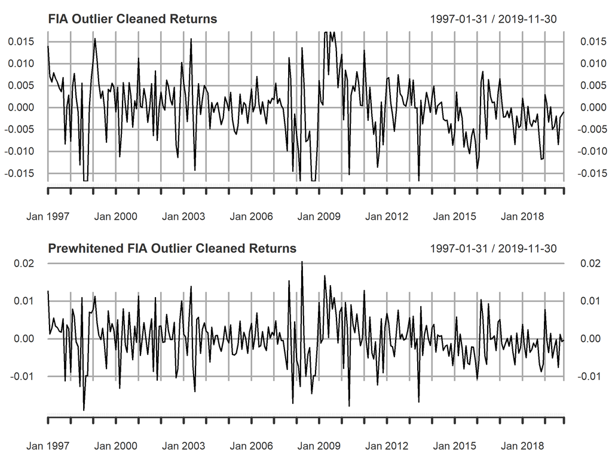

Figure 6: Outlier cleaned IF-transformed FIA returns and its prewhitened version.

```r
iftrFIAcl <- IF.Mean(returns = edhec$FIA, cleanOutliers = T)
PWiftrFIAcl <- IF.Mean(returns = edhec$FIA, cleanOutliers = T, prewhiten = T)
par(mfrow = c(2, 1))
plot(iftrFIAcl, main = "FIA Outlier Cleaned Returns", lwd = 0.8)
plot(PWiftrFIAcl, main = "Prewhitened FIA Outlier Cleaned Returns", lwd = 0.8)
```

For more information on all the features and visualization tools in the [*RPEIF*](https://CRAN.R-project.org/package=RPEIF) package, see https://CRAN.R-project.org/package=RPEIF, where a reference manual and vignette are provided.